# Modeling

Author

Varun Selvam

# Load Libraries

```r
pacman::p_load(tidyverse,e1071,caret,rminer,rpart,C50,tictoc,kernlab,snow,parallel,doParallel,randomForest,Matrix)
```

# Import Dataset

```r
cleaned_dataset <- read_csv("C:/Users/User/Box Sync/Business Analytics Degree/Semesters/Fall Semester 2024/IS 6812/EDA/Official_EDA/Train_Test_Files/train_clean.csv")
```

## Clean the Dataset

There were some changes that I did to the dataset like converting certain numeric and character columns to factors. However, when the file was exported to a csv after completing the EDA, that information was lost. Thus, to deal with that issue, some of the columns must be reconverted to factors.

```r
# Mutate any character variables into factors
cleaned_dataset <- cleaned_dataset %>% mutate_if(is.character, as.factor)

# Numeric Variables which should be factors stored as a vector
cat_values <- c("FLAG_EMP_PHONE","FLAG_WORK_PHONE","FLAG_EMAIL","FLAG_PHONE",'REG_REGION_NOT_WORK_REGION','LIVE_CITY_NOT_WORK_CITY',"REG_CITY_NOT_LIVE_CITY","REG_CITY_NOT_WORK_CITY","REGION_RATING_CLIENT_W_CITY","FLAG_DOCUMENT_3","FLAG_DOCUMENT_6","FLAG_DOCUMENT_8","REGION_RATING_CLIENT")

# Utilize mutate to transform all the columns in the cat_values vector to factors.
cleaned_dataset <- cleaned_dataset %>%
  mutate(across(all_of(cat_values), as.factor))

# Display the summary of train_clean
str(cleaned_dataset)
```

```
tibble [237,776 × 64] (S3: tbl_df/tbl/data.frame)
 $ SK_ID_CURR                  : num [1:237776] 1e+05 1e+05 1e+05 1e+05 1e+05 ...
 $ TARGET                      : num [1:237776] 1 0 0 0 0 0 0 0 0 0 ...
 $ NAME_CONTRACT_TYPE          : Factor w/ 2 levels "Cash loans","Revolving loans": 1 1 1 1 1 1 2 1 1 1 ...
 $ CODE_GENDER                 : Factor w/ 2 levels "F","M": 2 1 1 2 2 1 2 1 1 1 ...
 $ FLAG_OWN_CAR                : Factor w/ 2 levels "N","Y": 1 1 1 1 1 1 1 1 1 1 ...
 $ FLAG_OWN_REALTY             : Factor w/ 2 levels "N","Y": 2 1 2 2 2 2 2 2 2 2 ...
 $ CNT_CHILDREN                : num [1:237776] 0 0 0 0 0 0 0 1 0 0 ...
 $ AMT_INCOME_TOTAL            : num [1:237776] 202500 270000 135000 121500 99000 ...
 $ AMT_CREDIT                  : num [1:237776] 406598 1293503 312683 513000 490496 ...
 $ AMT_ANNUITY                 : num [1:237776] 24701 35699 29687 21866 27518 ...
 $ AMT_GOODS_PRICE             : num [1:237776] 351000 1129500 297000 513000 454500 ...
 $ NAME_TYPE_SUITE             : Factor w/ 7 levels "Children","Family",..: 7 2 7 7 6 1 7 7 1 7 ...
 $ NAME_INCOME_TYPE            : Factor w/ 8 levels "Businessman",..: 8 5 8 8 5 4 8 8 4 8 ...
 $ NAME_EDUCATION_TYPE         : Factor w/ 5 levels "Academic degree",..: 5 2 5 5 5 5 5 2 5 5 ...
```

[output cut: 50 more lines]

The code has read in the file and is now displaying some information such as whether it’s a character, factor, etc. for each variable.

# Build Majority Classifier

If the majority of applicants in this dataset do not default, then the majority class is “No Default”. The majority classifier will then predict “No Default” for everyone in the dataset.

## Check Class Prevalence

```r
# Display counts for the target variable and convert to a proportion.
prop.table(table(cleaned_dataset$TARGET)) %>% round(2) # Round to 2 decimal places.
```

```
   0    1
0.92 0.08
```

The proportion of 0 and 1 for the cleaned dataset is still the same. 0 represents `No Default` and while 1 represents `Default`. This means that the majority of clients in this dataset did not default.

## Get Counts of the Variables

```r
# Display counts for each level of the "TARGET" Variable
table(cleaned_dataset$TARGET)
```

```
     0      1
218531  19245
```

This just displays the counts for the target variable. There are 218,531 customers who did not default and there are 19,245 customers who did default.

## Code Majority Classifier

```r
# No and Yes Count
yes_count <- 218531
no_count <- 19245

# Calculate the total number of observations
total_count <- yes_count + no_count

# Majority class
majority_class <- ifelse(yes_count > no_count, 0, 1) # 1 if yes_count is greater than no count

# Convert Majority Class to factor
majority_class <- factor(majority_class)

#Generate the majority classifier predictions for all instances
predicted <- rep(majority_class, total_count) # Total count represents the total number of instances
# since majority class is zero, this will be repeated for every prediction or total number of instances.

# Create metrics list for Majority Classifier
metrics_list = c("ACC","TPR","PRECISION", "F1", "CONF", "AUC", "ROC")

# Generate metrics
majority_output <- mmetric(factor(cleaned_dataset$TARGET), predicted, metrics_list) #Set all the metrics generated by the mmetric function to an output.

majority_output_rounded <- lapply(majority_output, function(x) { # Utilize function to round off metrics to 2 decimal places.
  if (is.numeric(x)) {
    return(round(x, 2))
  } else {
    return(x)
  }
})

print(majority_output_rounded)
```

```
$res
       ACC       TPR1       TPR2 PRECISION1 PRECISION2        F11        F12
     91.91     100.00       0.00      91.91       0.00      95.78       0.00

$conf
      pred
target      0      1
     0 218531      0
     1  19245      0
```

TPR stands for Recall

The above code shows that the accuracy is 91.92% which rounds to 92%. The reason for this is because the majority classifier predicts the majority class which is “No Default”.

The majority classifier has an overall accuracy of 91.93%. This is however because the majority class is 0 which is “No Default”. (Majority Classifiers predict the majority class for everything which means that accuracy will be the majority class value.)

However since the objective is to predict the clients who can pay back their loans, the majority class accuracy can be used as the baseline accuracy. This also means that any future model will have to beat this majority class accuracy. (91.93%)

Although the accuracy of the majority model is interesting as a baseline metric, it might not be very useful due to the high class imbalance.

Thus, some additional metrics that may be desirable to be beat is `Precision 1`, `F1-1` or `ROC-AUC` .

It should be noted that beating the recall for 1(pay back loan) will not be possible since it is 100%. This is because TPR1 represents the majority class and the majority classifier will make no false negative errors. Thus, everything will be classified as positive which divided by the total positive observations results in 100.

ROC-AUC however is a measure of how well the model makes predictions in regards to different classes of the target variable. (This is measured by comparing the True Positive to the True Negative Rate.) This might be a more useful metric due to the imbalance and will reveal more interesting insights about the model.

- True Positive represents correctly predicting that somebody will be able to pack a loan.
- True Negative represents correctly predicting that somebody will have difficulty paying back a loan.
- False Negative represents incorrectly predicting difficulty paying back the loan.
- False Positive represents incorrectly predicting that somebody will pay back the loan when they actually will have difficulty paying back the loan.

# Build Random Classifier

```r
class_labels = c(0,1) # Create a class label with 2 labels, 0 and 1
class_labels <- factor(class_labels) # Convert Class labels to a factor

set.seed(123) # Set seed for reproducibility
predictions <- sample(x = class_labels, size = total_count,replace = TRUE, prob = c(.5,.5)) # Sample from the class label with replacement. Each observation has a 50% chance of being selected.

predictions <- factor(predictions) # Convert the predictions into a factor

random_output <- mmetric(factor(cleaned_dataset$TARGET),predictions,metrics_list) # Generate metrics


random_output_rounded <- lapply(random_output, function(x) { # Utilize function to round off metrics to 2 decimal places.
  if (is.numeric(x)) {
    return(round(x, 0))
  } else {
    return(x)
  }
})
print(random_output_rounded) # Print out the rounded metrics
```

```
$res
       ACC       TPR1       TPR2 PRECISION1 PRECISION2        F11        F12
        50         50         50         92          8         65         14

$conf
      pred
target      0      1
     0 109095 109436
     1   9704   9541

$roc
NULL

$lift
NULL
```

The Random Classifier model has an overall accuracy of 50% due to randomly assigning an observation to either default or no default with 50% probability.

Consequently, this has also affected recall which measures the following: predicted class/total observations in the actual class

The objective of any model built will be to have an accuracy higher than 50% and to have a higher recall (greater than TPR1), higher precision1, and a higher F11 score as well.

# Partition the Dataset

This is an important step, because it is possible that models can over fit. In other words, the model may learn noise in the data as opposed to actual patterns. Consequently, when the model sees new data, it won’t make accurate predictions and performance will instead plummet.

```r
# Make Zero the level to be modelled aka the positive class
cleaned_dataset$TARGET <- factor(cleaned_dataset$TARGET, levels = c("1", "0"))  # Set 0 as the positive class

cleaned_dataset <- cleaned_dataset %>%
  select(-SK_ID_CURR)

set.seed(123)
row_indexes <- createDataPartition(cleaned_dataset$TARGET,p=.7,list = FALSE) # This splits the dataset into train and test, while maintaining the class balance of the "TARGET" Variable.

train_set <- cleaned_dataset[row_indexes,] # subset 70% of rows from cleaned dataset to the train set.
test_set <- cleaned_dataset[-row_indexes,] # take all remaining rows which is 30% and move to the test set.
```

The Target Variable has been changed with Target becoming a factor and 0 becoming the second level. This is because R always models the second level of a factor by default.

Additionally, it should be noted that 0 - `No Default` is considered the positive class while 1 - `Default` is considered the negative class.

# Decision Tree

## Train Decision Tree

We’ll first build a simple decision tree model using all the predictors and the default hyper-parameters.

```r
tic() # See how long decision tree takes to model
tree_model <- rpart(formula = TARGET ~ ., data=train_set) # Create tree model using the rpart algorithm. Utilize all predictors
toc() # See how long decision tree takes to model
```

```
13.86 sec elapsed
```

This decision tree trained relatively quickly at 13.86 seconds.

## Display Tree Model

```r
tree_model # Display the tree model
```

```
n= 166444

node), split, n, loss, yval, (yprob)
      * denotes terminal node

1) root 166444 13472 0 (0.08094014 0.91905986) *
```

```r
summary(tree_model) # Important information about the tree model
```

```
Call:
rpart(formula = TARGET ~ ., data = train_set)
  n= 166444

  CP nsplit rel error xerror xstd
1  0      0         1      0    0

Node number 1: 166444 observations
  predicted class=0  expected loss=0.08094014  P(node) =1
    class counts: 13472 152972
   probabilities: 0.081 0.919
```

This decision tree is very simple, with no splits made due to the high class imbalance (92% positive class - No Default). Decision trees typically create splits to group similar observations, aiming to separate classes effectively. However, the imbalance in this dataset made it challenging to find meaningful splits.

While decision trees are powerful, they can overfit if the splits become too precise, capturing noise rather than meaningful patterns.

## Compute Evaluation Metrics

The below section will evaluate how this decision tree performs on various metrics for the train and test sets. The most important metric however is AUC-ROC.

### Evaluation Train Metrics

Evaluate Decision Tree Performance on the train set.

```r
tree_model_train_pred <- predict(tree_model,newdata = train_set) # Make predictions with the tree model on the train dataset

mmetric(train_set$TARGET,tree_model_train_pred,metrics_list) # Generate predictions with the tree model on the train dataset.
```

```
$res
       ACC       TPR1       TPR2 PRECISION1 PRECISION2        F11
  91.90599    0.00000  100.00000    0.00000   91.90599    0.00000

       F12       AUC
  95.78230   0.50000

$conf
      pred
target      1      0
     1      0  13472
     0      0 152972
```

The decision tree has a slightly lower accuracy then a majority classifier at 91.91%. The AUC-ROC is however not great at 0.5. A score of 0.5 indicates that the decision’s tree ability to distinguish between the two classes (default and no default) is as good as random guessing.

The model’s performance however on the minority class is not great with 0% on the minority F1 Score, Precision and Recall. In terms of recall, this means that the model failed to identify any instance of the negative class. This also adversely affects precision because if the model failed to identify any negative class, then one can’t correctly identify how much of the model’s predictions are negative.

Thus, this model is really good at identifying those who can pay back their loans, since they are the majority class. It however is not great at identifying defaulters since they are the minority class. (It would seem this tree model is almost exactly like a majority classifier since it’s performance with Accuracy and Recall is identical. Accuracy is slightly lower at 91.91% vs 92% for a majority classifier.)

### Evaluation Test Metrics

```r
tree_model_test_pred <- predict(tree_model,newdata = test_set) # Make predictions with tree model on test dataset

mmetric(test_set$TARGET,tree_model_test_pred,metrics_list) # Generate metrics with tree model predictions on the test datset
```

```
$res
       ACC       TPR1       TPR2 PRECISION1 PRECISION2        F11
  91.90686    0.00000  100.00000    0.00000   91.90686    0.00000

       F12        AUC
  95.78278    0.50000

$conf
      pred
target     1     0
     1     0  5773
     0     0 65559
```

The model maintains the same performance as the test set with an accuracy of 91.92%. All of the other metrics are the same for both the positive and negative class as well.

Overall, this decision tree generalizes well to new data since it maintains the same performance on the train set as well. It however also has the same issues like being unable to effectively distinguish between the majority class (no default) and minority class (default). The metrics are also similarly not very great for defaulters. The model struggles broadly based on precision, recall and F1 to identify defaulters.

# Decision Tree with Weights

A potential solution to deal with this class imbalance is to assign a greater weight to the minority class. We’ll use weight implementation with a Decision Tree.

## Create Weights

```r
# Set class weights (example: 10x weight for the minority class)
class_weights <- ifelse(cleaned_dataset$TARGET == 1, 10, 1)
```

Assign the weights to the class_weights variable. For minority, a weight of 10 is assigned. This means that the observations in the minority class will be considered 10 time more important than observations in the majority class.

It will also force the model to do splits that maximize the separation of the minority class due to the higher weights.

## Create Model with Weights

```r
# Fit rpart model with class weights
tic() # See how long model takes to train
tree_model_w <- rpart(TARGET ~ ., data = cleaned_dataset, weights = class_weights, method = "class")
toc() # See how long model takes to train
```

```
146.88 sec elapsed
```

This model was relatively quick to train at 2.45 minutes.

## Summary of Weighted Model

```r
tree_model_w
```

```
n= 237776

node), split, n, loss, yval, (yprob)
      * denotes terminal node

 1) root 237776 192450 0 (0.4682698 0.5317302)
   2) EXT_SOURCE_2< 0.4597299 78506  68187 1 (0.6021228 0.3978772)
     4) EXT_SOURCE_3< 0.3581222 21925  17328 1 (0.7262473 0.2737527) *
     5) EXT_SOURCE_3>=0.3581222 56581  50859 1 (0.5294275 0.4705725)
      10) EXT_SOURCE_2< 0.160342 10226   8535 1 (0.6645706 0.3354294) *
      11) EXT_SOURCE_2>=0.160342 46355  40310 0 (0.4878137 0.5121863)
        22) OCCUPATION_TYPE=Cleaning staff,Cooking staff,Drivers,HR staff,IT staff,Laborers,Low-skill Laborers,Sales staff,Security staff,Waiters/barmen staff 20020  17757 1 (0.5603288 0.4396712) *
        23) OCCUPATION_TYPE=Accountants,Core staff,High skill tech staff,Managers,Medicine staff,Private service staff,Realty agents,Secretaries,Unemployed 26335  17680 0 (0.4184913 0.5815087) *
   3) EXT_SOURCE_2>=0.4597299 159270  89260 0 (0.3725313 0.6274687)
     6) EXT_SOURCE_3< 0.4127227 44690  40448 1 (0.5118984 0.4881016)
      12) EXT_SOURCE_3< 0.2157927 12465  10711 1 (0.6208630 0.3791370) *
      13) EXT_SOURCE_3>=0.2157927 32225  24880 0 (0.4555358 0.5444642) *
     7) EXT_SOURCE_3>=0.4127227 114580  46840 0 (0.2988465 0.7011535) *
```

```r
summary(tree_model_w)
```

```
Call:
rpart(formula = TARGET ~ ., data = cleaned_dataset, weights = class_weights,
    method = "class")
  n= 237776

          CP nsplit rel error    xerror        xstd
1 0.18188101      0 1.0000000 1.0000000 0.001662213
2 0.01774227      1 0.8181190 0.8201715 0.001620175
3 0.01192864      3 0.7826345 0.7732398 0.001600957
4 0.01000000      6 0.7468485 0.7569966 0.001593468

Variable importance
               EXT_SOURCE_2                EXT_SOURCE_3
                         44                          34
       REGION_RATING_CLIENT REGION_RATING_CLIENT_W_CITY
                          4                           4
            OCCUPATION_TYPE      DAYS_LAST_PHONE_CHANGE
                          3                           3
                 DAYS_BIRTH           ORGANIZATION_TYPE
                          2                           2
    HOUR_APPR_PROCESS_START            NAME_INCOME_TYPE
                          1                           1
             FLAG_EMP_PHONE                 CODE_GENDER
                          1                           1

Node number 1: 237776 observations,    complexity param=0.181881
  predicted class=0  expected loss=0.4682698  P(node) =1
    class counts: 192450 218531
   probabilities: 0.468 0.532
  left son=2 (78506 obs) right son=3 (159270 obs)
  Primary splits:
      EXT_SOURCE_2    < 0.4597299  to the left,  improve=10533.350, (0 missing)
      EXT_SOURCE_3    < 0.4338475  to the left,  improve= 9857.361, (0 missing)
      EXT_SOURCE_1    < 0.4990603  to the left,  improve= 4347.691, (0 missing)
      OCCUPATION_TYPE splits as  RLLRLRRRLLRRRRLRLRL, improve= 3816.934, (0 missing)
      DAYS_BIRTH      < 15342.5    to the left,  improve= 3429.655, (0 missing)
  Surrogate splits:
      REGION_RATING_CLIENT        splits as  RRL, agree=0.623, adj=0.096, (0 split)
      REGION_RATING_CLIENT_W_CITY splits as  RRL, agree=0.623, adj=0.095, (0 split)
      DAYS_LAST_PHONE_CHANGE      < 238.5      to the left,  agree=0.611, adj=0.067, (0 split)
```

[output cut: 112 more lines]

```

Node number 13: 32225 observations
  predicted class=0  expected loss=0.4555358  P(node) =0.1328942
    class counts: 24880 29737
   probabilities: 0.456 0.544

Node number 22: 20020 observations
  predicted class=1  expected loss=0.4396712  P(node) =0.09826975
    class counts: 22630 17757
   probabilities: 0.560 0.440

Node number 23: 26335 observations
  predicted class=0  expected loss=0.4184913  P(node) =0.1027955
    class counts: 17680 24567
   probabilities: 0.418 0.582
```

## Compute Evaluation Metrics

The weighted decision tree will now be cross-validated with the train and test sets.

### Evaluation Train Metrics

```r
tree_model_w_train <- predict(tree_model_w,newdata = train_set) # Make predictions for weighted tree model on the train dataset.
mmetric(train_set$TARGET,tree_model_w_train,metrics_list) #Generate Metrics to analyze weighted tree model performance on the test dataset.
```

```
$res
       ACC       TPR1       TPR2 PRECISION1 PRECISION2        F11
73.4493283 53.5926366 75.1980755 15.9875996 94.8451568 24.6281894

       F12       AUC
83.8865877 0.6815838

$conf
      pred
target      1      0
     1   7220   6252
     0  37940 115032
```

The weighted decision tree does much better on the ROC-AUC metric at 0.68. This is much better than the regular Decision Tree which had a metric of 0.50. This means that model is doing a much better job at discriminating between the positive class (no default) and negative class (default).

ROC-AUC can go up to 1, so this model is doing relatively well on this metric. It also does better on all the metrics for the minority class as well. For instance, this model is able to identify 53.59% of all negative instances (default). This is significant progress since the un-weighted decision tree was at 0% for this recall.

Additionally, for precision, the minority class metric is at 16%. This much better then the un-weighted decision tree which was at 0%. In the context of Home Credit, this means that the model out of all the negative instances that weighted tree identified, 16% were actually negative. This in some ways is more concerning then accuracy because it costs more money (median of 24,412 dollars when someone defaults) compared to rejecting someone who could pay back the loan. (median of 23,800 dollars for incorrect rejections)

The F1 Score is much better when compared to the un-weighted decision tree model for the negative class at 24.63%. Although better than the un-weighted decision tree, it could still be better at striking a balance between the precision ad recall. 24.63% is a bit low.

### Evaluation Test Metrics

```r
# Make predictions with the Weighted Tree Model on the test set.
tree_model_w_test <- predict(tree_model_w,newdata = test_set)
mmetric(test_set$TARGET,tree_model_w_test,metrics_list) # Generate predictions on the test set to gauge model performance
```

```
$res
       ACC       TPR1       TPR2 PRECISION1 PRECISION2        F11
73.2532384 53.4384202 74.9980933 15.8400082 94.8164147 24.4366114

       F12         AUC
83.7507984   0.6787567

$conf
      pred
target     1     0
     1  3085  2688
     0 16391 49168
```

Thus this is a low variance model since it cannot adequately predict the minority class, but it does this consistently for both the train and test sets. It however has high bias because as previously mentioned, the performance is not great on any of the metrics for the minority class. (Model does however perform better than an un-weighted decision tree.)

# Naive_Bayes

The next model that will be examined is Naive Bayes, where the Bayes Theorem is used to classify instances.

## Build Model

The code chunk down below trains a Naive Bayes model on the train set.

```r
# Build the Naive Bayes Model utilizing the e1701 package.
tic() # See how long it takes model to train
nb_model <- naiveBayes(TARGET ~ ., data = train_set) # train the model on the train dataset.
toc() # See how long it takes model to train\
```

```
1.3 sec elapsed
```

This model was very quick to train with a total training time of 1.3 seconds.

## Summary of Naive_Bayes Model

The below code will display more information about the Naive Bayes Model.

```r
nb_model # Display naive bayes model
```

```
Naive Bayes Classifier for Discrete Predictors

Call:
naiveBayes.default(x = X, y = Y, laplace = laplace)

A-priori probabilities:
Y
         1          0
0.08094014 0.91905986

Conditional probabilities:
   NAME_CONTRACT_TYPE
Y   Cash loans Revolving loans
  1 0.93519893      0.06480107
  0 0.90263578      0.09736422

   CODE_GENDER
Y           F         M
  1 0.6209175 0.3790825
  0 0.7177261 0.2822739

   FLAG_OWN_CAR
Y           N         Y
  1 0.8210362 0.1789638
  0 0.7698468 0.2301532

   FLAG_OWN_REALTY
Y           N         Y
  1 0.3225950 0.6774050
  0 0.3043367 0.6956633

   CNT_CHILDREN
Y        [,1]      [,2]
  1 0.4053593 0.6565812
  0 0.3587062 0.6316833

   AMT_INCOME_TOTAL
Y       [,1]     [,2]
  1 145979.2 55964.00
  0 148537.0 58329.06
```

[output cut: 353 more lines]

```

   AMT_REQ_CREDIT_BUREAU_QRT
Y        [,1]      [,2]
  1 0.2137025 0.5801348
  0 0.2311534 0.5767163

   AMT_REQ_CREDIT_BUREAU_YEAR
Y       [,1]     [,2]
  1 1.853845 1.816936
  0 1.775632 1.769809

   House_Attribute_Low_Variance
Y           [,1]     [,2]
  1 -0.165075244 1.927351
  0  0.006168287 2.272093
```

```r
summary(nb_model) # Display a summary/key highlights from the model
```

```
          Length Class  Mode
apriori    2     table  numeric
tables    62     -none- list
levels     2     -none- character
isnumeric 62     -none- logical
call       4     -none- call
```

- Class 0 represents no default
- Class 1 represents default

The model has then calculated the conditional probabilities for each column. i.e
$$p(0) = p(ExtSource1|target = 0) *
p(ExtSource2|target = 0)* .... p(target = 0)$$

The p(target = 0) represents the apriori probability.

Since the apriori probability is simply the proportion of target variable’s levels this means that no default’s apriori probability will be 91.91% while default’s apriori probability is 8.09%.

The probability can also be calculated for the probability of no default as well:

i.e
$$p(1) = p(ExtSource1|target = 1) * p(ExtSource2
|target = 1) * ... p(target = 1)$$

Afterwards, whichever probability is the greater for each observation will be used to make the prediction. For instance, if the probability of “No Default” is .78 and the probability of “Default” is .45, the algorithm will classify the observation as “No Default”.

## Make Predictions

```r
tic() # Keep track of how long it took to make predictions
# Generate predictions on the train set using the naive bayes model
nb_train <- predict(nb_model,newdata = train_set,type = "raw")
# Generate predictions on the test set using the naive bayes model
nb_test <- predict(nb_model,newdata = test_set, type = "raw")
toc()
```

```
594.93 sec elapsed
```

## Compute Evaluation Metrics

This section contains the train and test set metrics for the Naive Bayes Model.

### Evaluation Train Metrics

```r
# Generate metrics for the model's train predictions
mmetric(train_set$TARGET,nb_train,metrics_list)
```

```
$res
       ACC       TPR1       TPR2 PRECISION1 PRECISION2        F11
82.5683113 37.2402019 86.5602855 19.6160463 93.9979271 25.6965786

       F12       AUC
90.1259189 0.6924399

$conf
      pred
target      1      0
     1   5017   8455
     0  20559 132413
```

The model seems to perform better than the regular Decision Tree.

The model did slightly better at discriminating between the two classes (default and no default) with an AUC of 0.6924. The weighted decision tree had an AUC of 0.6788.

In the context of Home Credit, this means that the Naive Bayes model is able to better distinguish between defaulting clients and non-defaulting clients in the dataset.

The Naive Bayes Model also performed better in some of the minority class metrics when compared to a decision tree. It should however be noted that the decision tree's performance was zero for the minority class. This means that any model that delivers non-zero results for the minority class will do better like the Weighted Decision Tree.

The Naive Bayes model does better in terms of precision and F1 Score when compared to the Weighted Decision Tree. The Weighted Decision Tree's precision score was 16% while Naive Baye's precision score was 19.62%. The F1 Score was also slightly better for Naive Bayes at 25.70% vs 24.63% for the Weighted Decision Tree.

This means that the Naive Bayes model is able to better balance recall and precision better than the Weighted Decision Tree for the negative class. The model's performance however for the positive class is better for recall and F1 score as well. For instance, the weighted decision tree's recall score was 75% while the Naive Bayes's score was 86.56%. The F1 score was also better at 90.13% for Naive Bayes compared to 83.75% for the Weighted Decision Tree. Naive Bayes does however come very close to the Weighted Decision Tree for the positive precision score as well. (Weighted Decision Tree Precision Score was 94.82% vs 94% for Naive Bayes Model.)

Accuracy is also higher overall, but as previously mentioned, not a very great metric due to the high class imbalance.

Hence, based on the train set, the Naive Bayes model seems comparable to Weighted Decision Tree. It also performs slightly better than the Weighted Decision Tree as well. The model however needs to be tested on the Test Set to fully gauge performance.

### Evaluation Test Metrics

```r
# Generate metrics for the model's test predictions
mmetric(test_set$TARGET,nb_test,metrics_list)
```

```
$res
       ACC       TPR1       TPR2 PRECISION1 PRECISION2        F11
82.5604217 36.6360644 86.6044326 19.4090117 93.9472160 25.3749250
       F12        AUC
90.1265140  0.6922606

$conf
      pred
target      1      0
     1   2115   3658
     0   8782  56777
```

This model’s test set metrics are very comparable to the train set metrics. Thus, this model is generalizing well to new data. This also indicates that the model is low on variance but moderately high on bias since some of the metrics for the negative class are low like precision which is at 19.41% or recall which is 36.64%.

Overall this model does not perform better then the Weighted Decision Tree which had more balanced metrics for the negative class. For instance, the Weighted Decision Tree’s metrics vs the Naive Bayes Model are:

Recall (Negative):

- 53.44 - Weighted Decision Tree
- **36.64 - Naive Bayes Model**

Precision (Negative):

- 15.84 - Weighted Decision Tree
- **19.41 - Naive Bayes Model**

F1 (Negative):

- 24.44 - Weighted Decision Tree
- **25.37 - Naive Bayes Model**

AUC:

- 0.6787 - Weighted Decision Tree
- **0.6922 - Naive Bayes Model**

This Naive Bayes Model does have a slightly higher AUC score which indicates that it’s better at discriminating between the positive and negative classes. However the Weighted Decision Tree has a much higher Recall at 53.44 vs 36.44 for the recall. Moreover all of the Weighted Decision Tree’s metrics are slightly lower for Precision and F1.

Thus, the Weighted Decision Tree is still better since it does better in Recall and only slightly worse in Precision and F1.

# Logistic Regression

This is the next model that will be built to predict default and no default.

## Build Logistic Regression Model

```r
tic() # Track how long model takes to train
logistic_model <- glm(TARGET ~ .  -House_Attribute_Low_Variance, data = train_set, family = binomial) # Train model, remove House_Attribute_Low_Variance, since it causes problems in the model
toc() # Track how long model takes to train
```

```
95.14 sec elapsed
```

## Summary of Logistic Regression Model

```r
# Get a key highlight of this model
summary(logistic_model)
```

```
Call:
glm(formula = TARGET ~ . - House_Attribute_Low_Variance, family = binomial,
    data = train_set)

Coefficients: (1 not defined because of singularities)
                                                   Estimate Std. Error z value
(Intercept)                                       3.134e+01  3.979e+02   0.079
NAME_CONTRACT_TYPERevolving loans                 1.361e-01  6.313e-02   2.156
CODE_GENDERM                                     -3.215e-01  2.500e-02 -12.861
FLAG_OWN_CARY                                     4.296e-01  4.822e-02   8.910
FLAG_OWN_REALTYY                                 -1.849e-02  2.133e-02  -0.867
CNT_CHILDREN                                     -2.687e-02  1.572e-02  -1.709
AMT_INCOME_TOTAL                                 -2.013e-07  2.027e-07  -0.993
AMT_CREDIT                                       -2.315e-06  1.566e-07 -14.781
AMT_ANNUITY                                      -1.178e-05  1.241e-06  -9.492
AMT_GOODS_PRICE                                   2.849e-06  1.786e-07  15.950
NAME_TYPE_SUITEFamily                             9.180e-02  9.499e-02   0.966
NAME_TYPE_SUITEGroup of people                   -2.511e-01  2.922e-01  -0.859
NAME_TYPE_SUITEOther_A                            3.015e-01  2.035e-01   1.482
NAME_TYPE_SUITEOther_B                           -7.490e-02  1.427e-01  -0.525
NAME_TYPE_SUITESpouse, partner                    1.490e-01  1.046e-01   1.424
NAME_TYPE_SUITEUnaccompanied                      3.780e-02  9.174e-02   0.412
NAME_INCOME_TYPECommercial associate             -1.040e+01  3.028e+02  -0.034
NAME_INCOME_TYPEMaternity leave                  -1.448e+01  3.028e+02  -0.048
NAME_INCOME_TYPEPensioner                         6.707e-01  3.682e+02   0.002
NAME_INCOME_TYPEState servant                    -1.044e+01  3.028e+02  -0.034
NAME_INCOME_TYPEStudent                           8.120e-01  3.285e+02   0.002
NAME_INCOME_TYPEUnemployed                       -2.270e+00  3.682e+02  -0.006
NAME_INCOME_TYPEWorking                          -1.051e+01  3.028e+02  -0.035
NAME_EDUCATION_TYPEHigher education              -1.064e+01  6.131e+01  -0.174
NAME_EDUCATION_TYPEIncomplete higher             -1.068e+01  6.131e+01  -0.174
NAME_EDUCATION_TYPELower secondary               -1.093e+01  6.131e+01  -0.178
NAME_EDUCATION_TYPESecondary / secondary special -1.088e+01  6.131e+01  -0.177
NAME_FAMILY_STATUSMarried                         1.197e-01  3.055e-02   3.919
NAME_FAMILY_STATUSSeparated                      -3.702e-02  4.548e-02  -0.814
NAME_FAMILY_STATUSSingle / not married            2.943e-02  3.565e-02   0.825
NAME_FAMILY_STATUSUnknown                         1.003e+01  5.354e+02   0.019
NAME_FAMILY_STATUSWidow                           7.393e-02  5.344e-02   1.384
NAME_HOUSING_TYPEHouse / apartment                1.893e-01  1.584e-01   1.195
NAME_HOUSING_TYPEMunicipal apartment              5.068e-02  1.651e-01   0.307
```

[output cut: 290 more lines]

```
AMT_REQ_CREDIT_BUREAU_DAY                        0.045789 *
AMT_REQ_CREDIT_BUREAU_WEEK                       0.468184
AMT_REQ_CREDIT_BUREAU_MON                        0.688042
AMT_REQ_CREDIT_BUREAU_QRT                        0.000125 ***
AMT_REQ_CREDIT_BUREAU_YEAR                       0.002470 **
---
Signif. codes:  0 '***' 0.001 '**' 0.01 '*' 0.05 '.' 0.1 ' ' 1

(Dispersion parameter for binomial family taken to be 1)

    Null deviance: 93561  on 166443  degrees of freedom
Residual deviance: 83627  on 166281  degrees of freedom
AIC: 83953

Number of Fisher Scoring iterations: 12
```

This shows key information for the Logistic Regression model. The information however can be a lot, so I have isolated the coefficients. Afterwards I have organized it in descending order.

### Order Coefficients in Descending Order

```r
# Extract the coefficients from the logistic regression model
log_coefficients <- logistic_model[["coefficients"]]

# Reordering the coefficients in descending order with sort function
sorted_coefficients <- sort(log_coefficients, decreasing = TRUE)

# View the sorted coefficients
print(sorted_coefficients)
```

```
                                     (Intercept)
                                    3.133979e+01
                       NAME_FAMILY_STATUSUnknown
                                    1.002664e+01
                                    EXT_SOURCE_3
                                    2.157405e+00
                                    EXT_SOURCE_2
                                    2.050918e+00
                  ORGANIZATION_TYPETrade: type 5
                                    1.262775e+00
              ORGANIZATION_TYPEIndustry: type 12
                                    1.029422e+00
                  ORGANIZATION_TYPETrade: type 4
                                    1.010649e+00
                       ORGANIZATION_TYPEMilitary
                                    1.007714e+00
            ORGANIZATION_TYPESecurity Ministries
                                    9.568355e-01
              ORGANIZATION_TYPETransport: type 1
                                    9.145273e-01
                         NAME_INCOME_TYPEStudent
                                    8.119607e-01
               ORGANIZATION_TYPEIndustry: type 9
                                    7.658051e-01
               ORGANIZATION_TYPEIndustry: type 5
                                    7.308444e-01
                  ORGANIZATION_TYPETrade: type 2
                                    7.158432e-01
                         ORGANIZATION_TYPEPolice
                                    7.117719e-01
              ORGANIZATION_TYPEIndustry: type 13
                                    7.076323e-01
                        ORGANIZATION_TYPEHousing
                                    6.833523e-01
                       NAME_INCOME_TYPEPensioner
                                    6.707406e-01
               ORGANIZATION_TYPEIndustry: type 6
                                    6.451178e-01
                     ORGANIZATION_TYPEUniversity
                                    6.294795e-01
```

[output cut: 271 more lines]

```
                                   -1.049159e+01
                         NAME_INCOME_TYPEWorking
                                   -1.050958e+01
             NAME_EDUCATION_TYPEHigher education
                                   -1.064172e+01
            NAME_EDUCATION_TYPEIncomplete higher
                                   -1.068402e+01
NAME_EDUCATION_TYPESecondary / secondary special
                                   -1.088036e+01
              NAME_EDUCATION_TYPELower secondary
                                   -1.092728e+01
                 NAME_INCOME_TYPEMaternity leave
                                   -1.448357e+01
                     ORGANIZATION_TYPEUnemployed
                                   -2.113619e+01
```

`NAME_FAMILY_STATUSUnknown` and `Ext_Source_2` and `Ext_Source_3` are shown as important predictors in successful repayment. The coefficients are in log-odds which makes the exact interpretation difficult. However, since these coefficients are bigger then the other coefficients, we can tell that these predictors have the most influence. Moreover, the sign is positive which indicates that a one unit increase in these predictors increases the log-odds of successfully repaying a loan.

`NAME_FAMILY_STATUSUnknown` however is a factor but for anyone in the “Unknown” category, the log-odds of repayment increase. This does seem a little strange, one would think that one with a known family status might have a better chance of paying back a loan. It additionally is not statistically significant at a significance level of .05. Thus, the reliability of this third predictor is questionable. The other two predictors however are statistically significant at a significance level of .05

## Make Predictions

Generate predictions for the train and test sets. It should be noted that Logistic Regression produces probabilities as predictions. Thus, a threshold has to be selected to convert the probabilities to class labels.

In the context, of Homecredit, there are 2 values in the `Target` Variable, “0” or “1”. The Target Variable has already been converted to a factor with “0” as the second level. Thus, no changes are required for the Target Variable. However, a threshold must still be decided will be 0.9. This is because the classes are severely imbalanced which means that the model will be able to better predict the majority class. Thus, to mitigate this issue, a very high threshold of 0.9 will be selected. This will force the model to only classify someone as no default if their probability of paying the loan off is very high.

```r
# Convert probabilities to binary class predictions (0 or 1)
threshold <- 0.9

# Train Predictions
lm_train_probs <- predict(logistic_model, newdata = train_set, type = "response") # Use Response to get the predictions as probabilities for Logistic Regression
lm_train <- factor(ifelse(lm_train_probs > threshold, "0", "1"), levels = c("1", "0")) # Convert the probablities to class labels

# Test Predictions
lm_test_probs <- predict(logistic_model, newdata = test_set, type = "response") # Use Response to get the predictions as probabilities for Logistic Regression
lm_test <- factor(ifelse(lm_test_probs > threshold, "0", "1"), levels = c("1", "0")) # Convert the probablities to class labels
```

## Evaluate Model

Metrics will now be computed to evaluate the model’s performance on the train and test metrics.

### Evaluation Train Metrics

```r
# Train Metrics
mmetric(train_set$TARGET, factor(lm_train,levels = c(1,0)),
metrics_list)
```

```
$res
       ACC       TPR1       TPR2 PRECISION1 PRECISION2        F11
  75.34666   57.98694   76.87551   18.08920   95.40801   27.57598

       F12
  85.14499

$conf
      pred
target      1      0
     1   7812   5660
     0  35374 117598
```

The Logistic Regression Model’s performance is comparable to the other models. For instance, it’s Recall for the negative class is better at 58% vs the Weighted Decision Tree’s recall which is only 53.44%. This is 4.41% better then the Weighted Decision Tree. Additionally, the precision (18.09%) and F1 (27.58%) scores are also higher when compared to a Weighted Decision Tree, (15.84%) and (24.44%) respectively.

Like the other models it does better on the positive class with fairly high metrics such as 95.41% for Precision. It also seems to do better then Naive Bayes. The model still however needs to be cross-validated to make sure that its performance is consistent.

### Evaluation Test Metrics

```r
# Test Metrics
mmetric(factor(test_set$TARGET,levels = c("1","0")),factor(lm_test,levels = c("1","0")),metrics_list)
```

```
$res
       ACC       TPR1       TPR2 PRECISION1 PRECISION2        F11
  75.22571   57.50909   76.78580   17.90819   95.35355   27.31162

       F12
  85.06827

$conf
      pred
target     1     0
     1  3320  2453
     0 15219 50340
```

The Logistic Regression’s model’s performance on the test set is fairly consistent with its train set performance. There is a very minor drop in all the metrics when train and test sets are compared. This also means that the interpretations about the Weighted Decision Tree still hold. Since Logistic Regression’s performance against the Weighted DecisionTree has been compared, we’ll now compare this model’s performance to Naive Bayes.

Logistic Regression does better in terms of Recall, and F1 score and is only slightly lower then Naive Bayes in terms of precision.

Recall (Negative):

- 36.64 - Naive Bayes Model
- **57.51 - Logistic Regression**

Thus, Logistic Regression seems than Naive Bayes since it’s performance with the positive class is comparable. Additionally it does better in all of the metrics for the negative class except for precision. This however is by a relatively low amount (1.5%)

# Random Forest

Random Forest is an ensemble method that uses several decision trees to make classification predictions. It however is very computationally intensive and is prone to overfitting. Thus, to mitigate this issue, I will model a very simple Random Forest, since very complicated Random Forest Models overfit.

## Pre Process the Data for Random Forest

The train dataset will be converted into a matrix and then all of the variables will be placed into “x” which is all the predictors. “y” will represent the “TARGET” variable.

```r
# Convert categorical variables to dummy variables
train_data_clean <- model.matrix(TARGET ~ . - 1, data = cleaned_dataset) # Remove the target variable from the dataset.

# Set up independent and dependent variables
x <- as.data.frame(as.matrix(train_data_clean))
y <- as.factor(cleaned_dataset$TARGET)

# Reorder the levels in "y" to make "0" the second level
y <- factor(y,levels = c(1,0))
```

### Partition the Dataset

```r
# Subset data for testing
set.seed(123) # Set seed for reproducibility

# Sample 20% of the data and assign to sample_index
sample_index <- sample(1:nrow(x), size = 0.2 * nrow(x))

# train set w/ all predictors and no target variable
x_sub_train <- x[sample_index, ] # Subset all predictors to x_sub
# target variable from test set
y_sub_train <- y[sample_index] # Subset target variable to y_sub

# test set w/ all predictors and no target variable
x_sub_test <- x[-sample_index,] # Subset all predictors to x_sub_test
y_sub_test <- y[-sample_index] # Subset all predictors to y_sub_test
```

## Train the Model

```r
tic()
set.seed(123)
# Train Random Forest on subset with reduced trees and features
rf_model <- randomForest(x_sub_train, y_sub_train, ntree = 50, mtry = log(ncol(x)), importance = TRUE)
toc()
```

```
431.79 sec elapsed
```

## Model Information

### Model Summary

```r
print(rf_model) # Print model summary
```

```
Call:
 randomForest(x = x_sub_train, y = y_sub_train, ntree = 50, mtry = log(ncol(x)),      importance = TRUE)
               Type of random forest: classification
                     Number of trees: 50
No. of variables tried at each split: 5

        OOB estimate of  error rate: 8.01%
Confusion matrix:
   1     0  class.error
1  5  3797 0.9986849027
0 10 43743 0.0002285558
```

The overall out-of-bag (OOB) error is approximately 8%, which means the model misclassified around 8% of the observations. OOB error is an internal estimate of test error in Random Forests.

However to a get a full understanding, we’ll still cross-validate Random Forest with the train and test sets.

### Extract Important Features

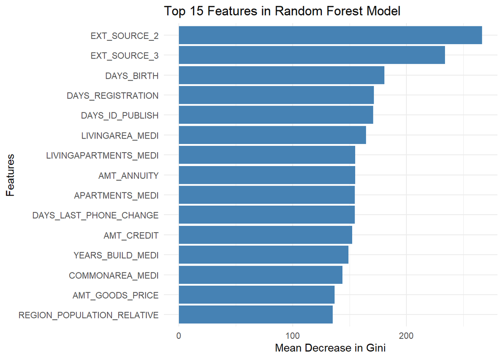

```r
# Extract feature importance and select top 15 features for better visualization
importance_df <- as.data.frame(importance(rf_model))
importance_df$Feature <- rownames(importance_df)
top_features <- importance_df %>%
  arrange(desc(MeanDecreaseGini)) %>%
  top_n(15, MeanDecreaseGini)

# Plot top 15 feature importance using ggplot2
ggplot(top_features, aes(x = reorder(Feature, MeanDecreaseGini), y = MeanDecreaseGini)) +
  geom_bar(stat = "identity", fill = "steelblue") +
  coord_flip() +  # Flip coordinates for horizontal bar chart
  labs(title = "Top 15 Features in Random Forest Model",
       x = "Features",
       y = "Mean Decrease in Gini") +
  theme_minimal()
```

This plot is based on the Gini Index which measures impurity or the probability of something being erroneously categorized. A predictor with a lower Gini Index indicates that the feature does a good job at reducing “uncertainty”.

The top 3 important features are `EXT_SOURCE_2`, `EXT_SOURCE_3` and `DAYS_BIRTH`. These predictors also very important for reducing impurity in the model as well.

This indicates that at two of the top most important predictors are `EXT_SOURCE_2` and `EXT_SOURCE_3` since they appear in every model.

# Generate Predictions

The code down below will generate predictions utilizing the Random Forest Model on the train and test sets. It will also help us get a full understanding of Random Forest’s performance. Random Forest’s model summary indicated that the results are not great for the minority class. Cross-Validation will however help us confirm or repudiate those results.

```r
# Generate for the training data
predictions_train <- predict(rf_model, newdata = x_sub_train)

# Make predictions on the tesing data
predictions_test <- predict(rf_model, newdata = x_sub_test)
```

Predictions have been sucessfully generated for the train and test sets.

## Generate Train Metrics

This code generates the metrics for the model’s performance on the train set.

```r
# Train Metrics
mmetric(y_sub_train,predictions_train,metric = metrics_list)
```

```
$res
       ACC       TPR1       TPR2 PRECISION1 PRECISION2        F11
  96.62706   57.81168  100.00000  100.00000   96.46361   73.26667

       F12
  98.19998

$conf
      pred
target     1     0
     1  2198  1604
     0     0 43753
```

The model seems to do very well with high metrics for the positive class. classes. This model’s metrics are actually higher than the rest of the models for both classes. The accuracy is even higher as well by 4.71%. (The majority classifier had an accuracy of 91.92%.)

These are the negative class metrics for the other 3 models:

Recall (Negative):

- 57.51 - Logistic Regression
- 36.64 - Naive Bayes Model
- **57.81 - Random Forest**

The above metrics show that Random Forest is doing much better with the negative class when compared to the other models. This is spite of the high error rate for the minority class from the model summary.

However this great model performance must be cross-validated to ensure that the model is not overfitting.

## Generate Test Metrics

This code generates the metrics for the model’s performance on the test set.

```r
# Test Metrics
mmetric(y_sub_test,predictions_test,metric = metrics_list)
```

```
$res
       ACC       TPR1       TPR2 PRECISION1 PRECISION2        F11
  91.88155    0.00000  100.00000    0.00000   91.88155    0.00000

       F12
  95.76903

$conf
      pred
target      1      0
     1      0  15443
     0      0 174778
```

This indicates that the Random Forest will need more hyper-parameter tuning to increase generalization to new data. I made the model fairly simple to avoid overfitting, but this does not seem to be very effective. It would appear that other parameters like regularization will need to be included, to improve Random Forest’s performance.

Finally, it appears that the model’s summary was correct, which cross validation has further proved. The model struggles to classify the minority class.

# Final Thoughts

Overall this was an interesting experience with building all of these models. The key takeaways I have learned are that the predictors may not be the same across all of the models. However, there will be a few predictors that appear commonly across all the models. We can take those predictors and use them to make inferences about what the biggest associations are with successful repayment.

Additionally techniques like weights help with improving model performance along with using some simpler models like Logistic Regression or Naive Bayes to get some insights.

However Class Imbalance still remains an issue that must be addressed through other techniques like under-sampling, etc. I will be experimenting more on these techniques with my group.